# Aprendizaje No Supervisado

¿Qué país se parece más a Colombia?

Oscar Bustos

# Una pregunta difícil

## ¿Qué país se parece más a Colombia?

**Predicción inicial — 90 segundos**

1. Escriba un país sin consultar los datos.
2. Anote las características que sustentan su elección.
3. Vote: ¿Ecuador, Perú, México, otro país?

Guardaremos la respuesta. Todavía no sabemos qué significa **parecido**.

## La pregunta está incompleta

**¿Parecido respecto a qué?**

- Economía
- Salud
- Demografía
- Comercio

**¿Parecido para qué?**

- Diseñar una política
- Comparar un mercado
- Buscar un referente
- Detectar una anomalía

## Toda respuesta necesita un propósito

Colombia se parece a ______

respecto a ______

para decidir ______.

Las variables expresan una hipótesis; la distancia la convierte en geometría.

## Solo podemos comparar lo observado

| Dimensión | Variables disponibles |
| --- | --- |
| Salud | Mortalidad infantil, gasto en salud, esperanza de vida |
| Demografía | Fertilidad total |
| Ingreso | Ingreso por persona, PIB (Producto Interno Bruto) per cápita |
| Comercio | Exportaciones e importaciones |
| Estabilidad | Inflación |

No observamos cultura, idioma, instituciones, desigualdad interna ni geografía.

# Primera respuesta: dos variables

## Conceptos y términos fundamentales

| Término / Sigla | Definición conceptual |
| --- | --- |
| **Instancia** | Caso u observación representado como vector de datos |
| **Variable** | Atributo o medición numérica de una instancia |
| **PIB** | Producto Interno Bruto: valor monetario por habitante |
| **Distancia ($d$)** | Función que cuantifica la disimilitud entre dos puntos |
| **Estandarización ($z$)** | Transformación lineal a media 0 y varianza unitaria |

## Cada métrica define una geometría

| Métrica | Símbolo | Ecuación | Aplicación típica |
| --- | --- | --- | --- |
| **Euclidiana** | $L_2$ | $\sqrt{\sum_{j=1}^p (x_j - y_j)^2}$ | Variables continuas en escala comparable |
| **Manhattan** | $L_1$ | $\sum_{j=1}^p \vert x_j - y_j \vert$ | Espacios en cuadrícula; robusta a atípicos |
| **Chebyshev** | $L_\infty$ | $\max_j \vert x_j - y_j \vert$ | Peor caso o discrepancia límite tolerada |
| **Jaccard** | $d_J$ | $1 - \frac{\vert A \cap B \vert}{\vert A \cup B \vert}$ | Presencia/ausencia en atributos binarios |
| **Coseno** | $d_{\cos}$ | $1 - \frac{\mathbf{x} \cdot \mathbf{y}}{\\|\mathbf{x}\\|_2 \\|\mathbf{y}\\|_2}$ | Texto y embeddings (compara dirección) |

## Dos variables permiten empezar

Usaremos una representación deliberadamente simple:

$$\mathbf{x}_{país}=(\text{PIB per cápita},\ \text{mortalidad infantil})$$

**Pregunta:** ¿qué significa que dos países estén cerca en este plano?

Que difieren poco en esas dos mediciones, según la escala y métrica elegidas.

## ¿Sumar importa igual que multiplicar?

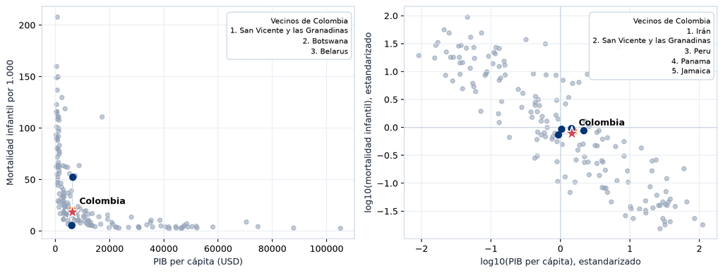

Unidades originales (PIB domina la distancia) frente a transformación logarítmica estandarizada.

167 países. Cálculo reproducible en `country_narrative.py`.

## La escala cambia el vecino

**Unidades originales**

PIB per cápita domina la distancia.

Colombia → **San Vicente y las Granadinas**

**Logaritmo + estandarización**

Primero compara cambios relativos; luego iguala dispersión.

Colombia → **Irán**

## Log + estándar define la geometría

$$u_{ij}=\log_{10}(x_{ij}),
\qquad z_{ij}=\frac{u_{ij}-\bar u_j}{s_{u_j}}$$

- El logaritmo comprime colas derechas.
- Diferencias logarítmicas representan razones.
- Estandarizar vuelve comparables las dispersiones.
- No demuestra que la distancia euclidiana sea adecuada.

## Irán es una respuesta correcta…

| País | PIB per cápita (USD) | Mortalidad (por 1.000) | Distancia $L_2$ (log + std) |
| --- | --- | --- | --- |
| **Colombia** (base) | 6 250 | 18,6 | — |
| **Irán** | 6 530 | 19,3 | **0,043** |
| San Vicente y Granadinas | 6 230 | 20,7 | 0,093 |
| Perú | 5 020 | 20,3 | 0,165 |

Distancia euclidiana sobre variables con logaritmo y estandarización.

**Objeción:** ¿qué ocurrió con las otras siete variables disponibles?

# PCA: mirar nueve variables

## Nueve dimensiones no caben en la pantalla

- Con dos variables podemos dibujar un plano.
- Con nueve variables podemos calcular distancias.
- Pero no podemos observar directamente el vecindario.
- Escoger dos columnas descartaría información por decisión humana.

**¿Podemos construir dos ejes usando las nueve variables?**

## PCA construye nuevas direcciones

El **Análisis de Componentes Principales (PCA)** busca ejes de máxima varianza:

$$\mathbf z_1=\mathbf X\mathbf v_1,
\qquad
\mathbf v_1=\arg\max_{\|\mathbf v\|=1}\operatorname{Var}(\mathbf X\mathbf v)$$

Cada componente es una combinación de las variables originales.

## PCA no selecciona dos columnas

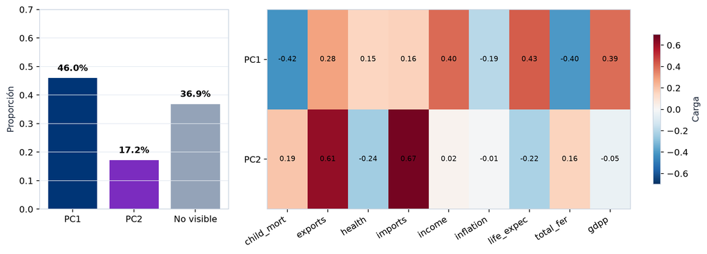

Varianza explicada por componente (izquierda) y matriz de cargas sobre las nueve variables (derecha).

PCA ajustado sobre las nueve variables estandarizadas.

## El mapa conserva 63,1% de la variación

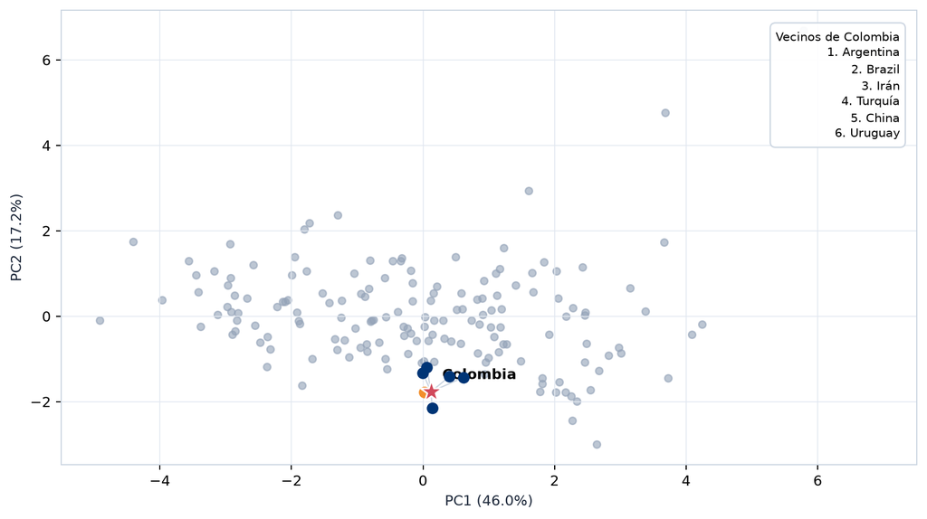

Proyección 2D del espacio de 9 dimensiones y vecinos más cercanos de Colombia.

Componentes principales: PC1 = 46,0%; PC2 = 17,2%. Colombia → Argentina.

## Vecinos en la proyección PCA 2D

| País | PC1 (46,0%) | PC2 (17,2%) | Distancia $L_2$ (2D) |
| --- | --- | --- | --- |
| **Colombia** (base) | 0,12 | -1,77 | — |
| **Argentina** | 0,02 | -1,78 | **0,099** |
| Brasil | 0,14 | -2,15 | 0,383 |
| Irán | -0,00 | -1,33 | 0,451 |
| Turquía | 0,40 | -1,41 | 0,454 |

En el plano proyectado, Colombia y Argentina son prácticamente indistinguibles.

## Vecinos con 9 variables (PCA total)

| País | Distancia $L_2$ (9D) | Puesto en 9D | Puesto en PCA 2D |
| --- | --- | --- | --- |
| **Turquía** | **0,749** | 1.° | 4.° ($d=0,454$) |
| **Uruguay** | **0,757** | 2.° | 6.° ($d=0,601$) |
| **Brasil** | **0,862** | 3.° | 2.° ($d=0,383$) |
| Ecuador | 0,965 | 4.° | 9.° ($d=0,732$) |
| *Argentina* | 1,718 | **21.°** | **1.°** ($d=0,099$) |

Al usar todas las variables, Argentina cae del 1.° al 21.° lugar ($d=1,718$).

## PCA permite ver; no decide la verdad

**Para visualizar**

- Proyectar países y modelos a 2D.
- Explorar estructura y casos extremos.
- Comunicar patrones.

**Para modelar**

- Conservar más componentes si se requiere.
- Validar qué información se pierde.
- No confundir varianza con utilidad.

## Actividad: construya una proyección

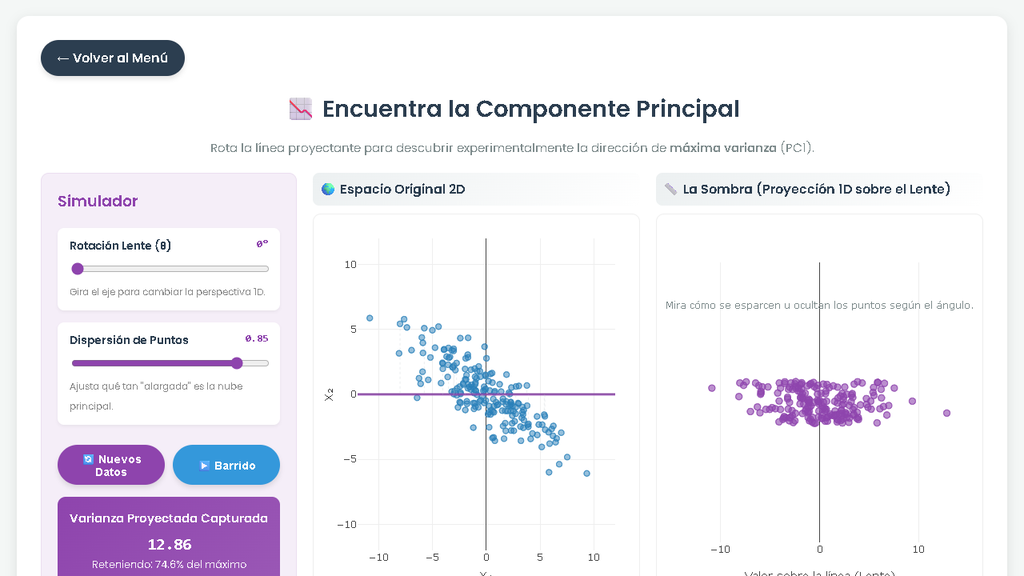

**Reto guiado — 7 min**

1. Cambie la dirección proyectada.
2. Compare la vista 2D y 1D.
3. Identifique qué se conserva.
4. Explique qué se pierde.

🔗 [Abrir PCA](https://oscar-bustos.github.io/javeriana-tallerml/reduccion_dimension/pca.html)

## Proyección no lineal con t-SNE

**t-SNE** (*t-Distributed Stochastic Neighbor Embedding*):

```python
from sklearn.manifold import TSNE

tsne = TSNE(
    n_components=2,
    perplexity=30,
    random_state=42,
)
Z = tsne.fit_transform(X)
```

**3 más cercanos en t-SNE:**

1. **Turquía** ($d = 0,54$)
2. **Brasil** ($d = 0,68$)
3. **Ecuador** ($d = 0,92$)

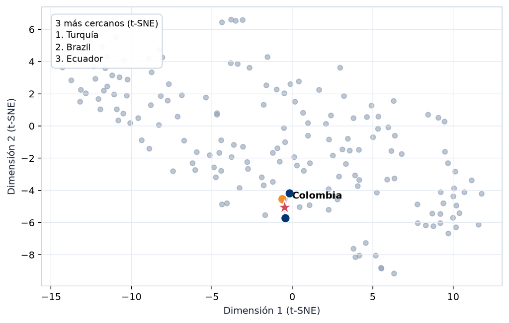

Proyección t-SNE 2D de las nueve variables estandarizadas.

# K-Means: de vecinos a perfiles

## Un vecino responde una pregunta local

**Vecino más cercano**

- Recupera un caso individual.
- Depende de variables y distancia.
- Colombia → Turquía en 9D.

**Clustering**

- Resume toda la colección.
- Busca perfiles globales.
- Requiere supuestos adicionales.

**¿Cómo resumiríamos 167 países con pocos prototipos?**

## K-Means representa cada grupo por su media

Para grupos $C_1,\dots,C_K$ y centroides $\boldsymbol\mu_k$:

$$J=\sum_{k=1}^{K}\sum_{\mathbf x_i\in C_k}
\|\mathbf x_i-\boldsymbol\mu_k\|_2^2$$

La media minimiza la suma de distancias cuadradas dentro del grupo.

## Lloyd alterna dos preguntas

```python
while not converged:
    labels = nearest(
        X, centroids)
    centroids = means(
        X, labels)
```

1. ¿Cuál centro está más cerca?
2. ¿Dónde queda la nueva media?

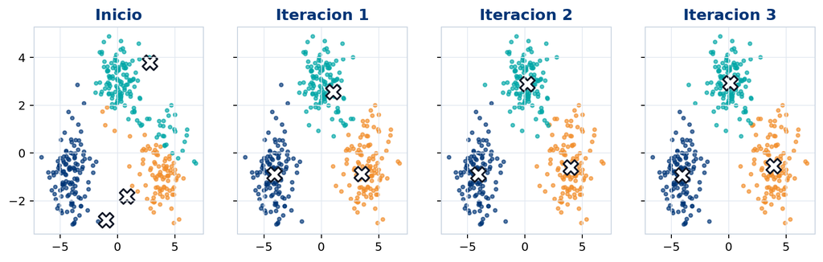

Cuatro pasos del algoritmo de Lloyd: asignación al centroide más cercano y reubicación del centroide.

## Actividad: controle los centroides

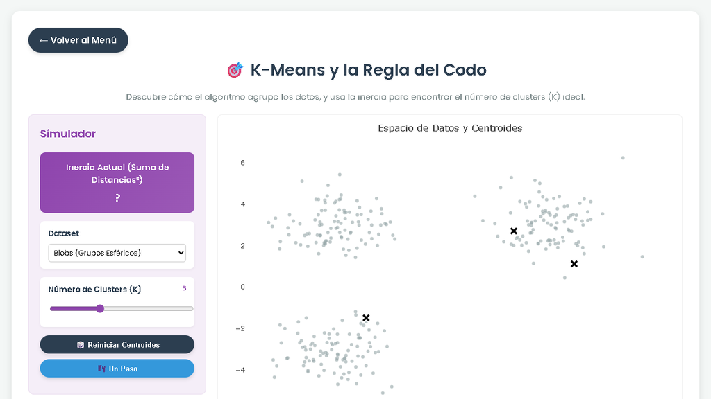

**Reto guiado — 7 min**

1. Cambie el número de grupos.
2. Reinicie los centroides.
3. Observe las asignaciones.
4. Compare inercia e iteraciones.

🔗 [Abrir K-Means](https://oscar-bustos.github.io/javeriana-tallerml/clustering/kmeans.html)

## ¿Cuántos perfiles debemos pedir?

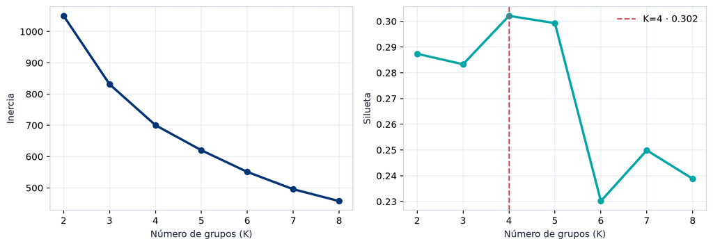

Curva de inercia (codo) y coeficiente de silueta media para evaluar la partición en K grupos.

Modelos K-Means sobre las nueve variables estandarizadas; 30 reinicios por K.

## Las métricas no reemplazan el propósito

- La inercia siempre disminuye al aumentar $K$.
- La silueta compara cohesión y separación.
- En estos datos, la silueta máxima ocurre en $K=4$.
- Su valor es solo **0,302**: la separación no es fuerte.
- También necesitamos estabilidad e interpretación.

## K-Means agrupa en 9D

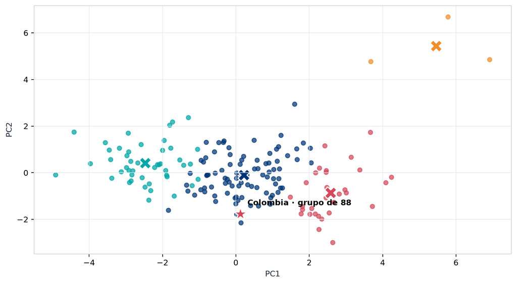

Clústeres (K=4) y centroides calculados en 9 dimensiones, visualizados mediante proyección PCA.

El modelo usa las nueve variables; PCA solo proyecta etiquetas y centroides.

## Colombia comparte perfil con 87 países

Para $K=4$:

- Colombia pertenece a un grupo de **88 países**.
- Turquía es su vecino más cercano dentro del espacio completo.
- Uruguay, Brasil, Ecuador y R. Dominicana también están cerca.
- El identificador del grupo es arbitrario.

**¿Un grupo tan grande constituye una respuesta útil?**

## Los centroides convierten grupos en perfiles

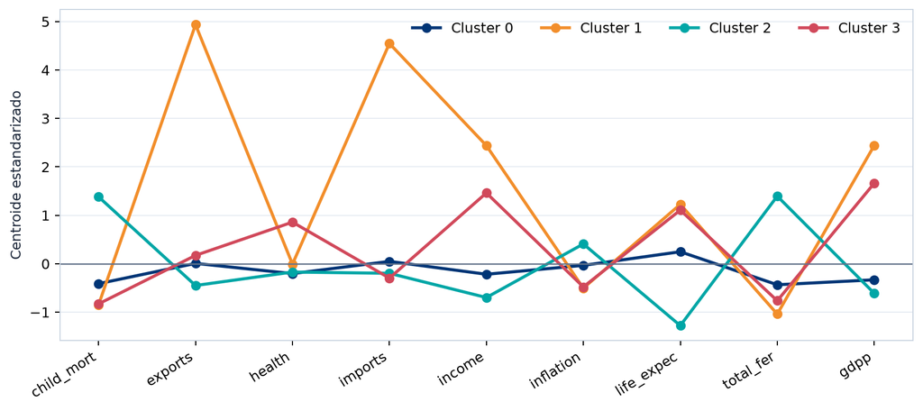

Coordenadas de los centroides estandarizados para cada uno de los cuatro clústeres.

Valores positivos superan el promedio global estandarizado.

## Interpretar clústeres con un árbol

Un **árbol sustituto** (*surrogate model*) entrena sobre las etiquetas de K-Means para extraer reglas legibles:

```python
from sklearn.tree import DecisionTreeClassifier

surrogate = DecisionTreeClassifier(
    max_leaf_nodes=4, random_state=42
).fit(X_scaled, kmeans.labels_)

fidelity = surrogate.score(X_scaled, kmeans.labels_)  # 97,0%
```

- Traduce centroides 9D a umbrales directos de decisión.
- Mide la **fidelidad**: qué tan bien el árbol reproduce a K-Means.
- El árbol explica la partición; no prueba que los grupos sean naturales.

## Reglas del árbol sustituto

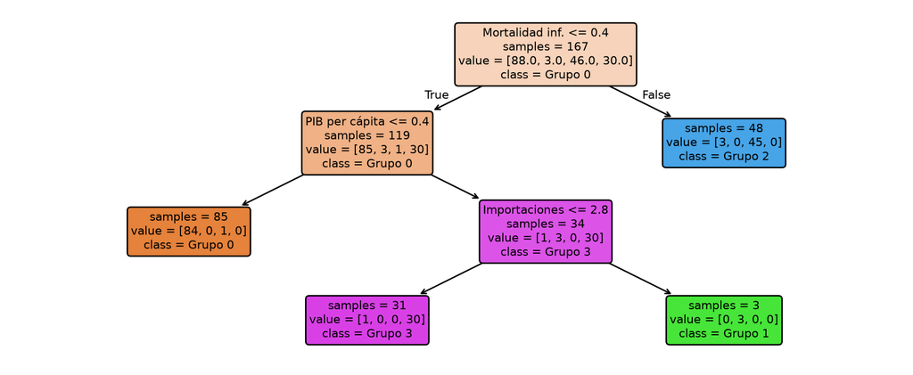

Árbol podado (4 hojas) que reproduce K-Means con 97,0% de fidelidad.

Mortalidad infantil y PIB dividen los grupos; importaciones aíslan los centros comerciales.

## K-Means siempre obliga a escoger

**País central**

Está claramente cerca de un centroide.

La etiqueta parece razonable.

**País fronterizo**

Está casi a igual distancia de dos centroides.

K-Means igualmente asigna una sola etiqueta.

**¿Podemos conservar la incertidumbre?**

# GMM: pertenencia probabilística

## Una frontera puede ser gradual

En lugar de una etiqueta única, buscamos:

$$P(z_i=k\mid\mathbf x_i)$$

**Pregunta:** ¿qué significaría que un país tenga 54% de afinidad con un perfil y 46% con otro?

## GMM modela una mezcla de poblaciones

Los **Modelos de Mezcla Gaussiana (GMM)** suponen una combinación de normales:

$$p(\mathbf x)=\sum_{k=1}^{K}\pi_k\,
\mathcal N(\mathbf x\mid\boldsymbol\mu_k,\boldsymbol\Sigma_k)$$

- $\pi_k$: prevalencia del componente.
- $\boldsymbol\mu_k$: centro.
- $\boldsymbol\Sigma_k$: tamaño, forma y orientación.

## GMM permite expresar duda

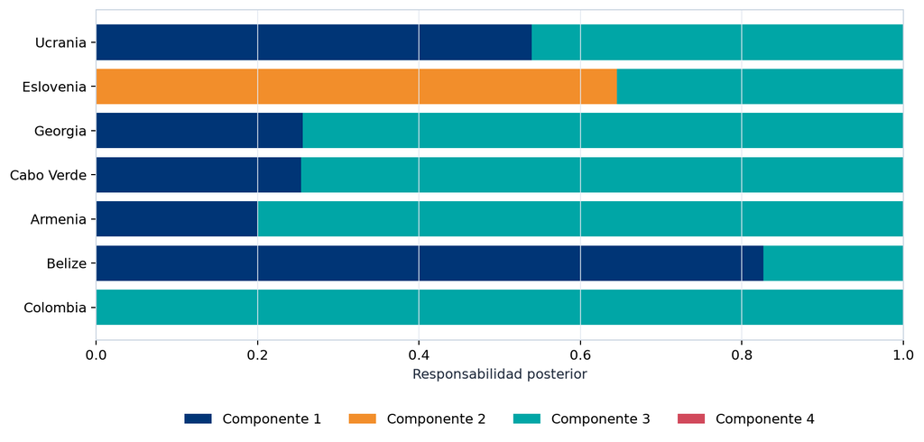

Responsabilidades posteriores por componente para países con mayor incertidumbre y Colombia.

GMM de cuatro componentes y covarianza completa, ajustado en 9D.

## La incertidumbre también es un resultado

- Ucrania queda aproximadamente 54% frente a 46%.
- Eslovenia queda aproximadamente 65% frente a 35%.
- Colombia tiene responsabilidad máxima de **99,98%**.
- GMM permite pertenencia suave; no obliga a que exista duda.

**¿Qué capacidad adicional aporta la covarianza?**

## Las elipses resuelven la anisotropía

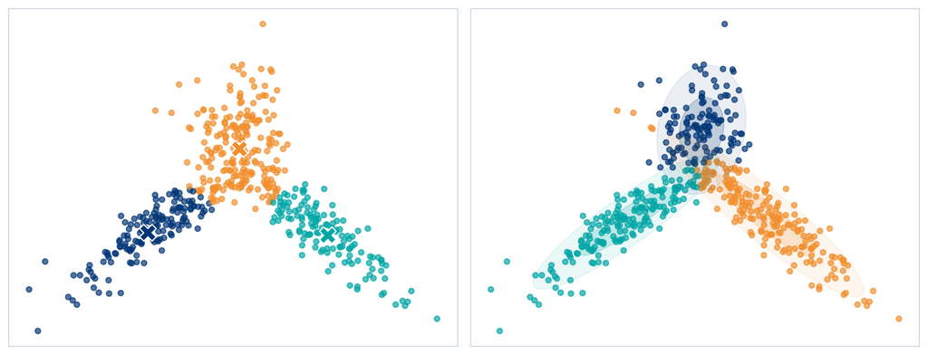

Comparación en datos anisotrópicos: K-Means (izquierda: distancia al centro) frente a GMM (derecha: covarianza completa).

Simulación reproducible con grupos elipsoidales y orientaciones diferentes.

## GMM cambia dos supuestos de K-Means

| Supuesto | K-Means | GMM con covarianza completa |
| --- | --- | --- |
| Pertenencia | Una etiqueta | Probabilidades |
| Geometría | Cercanía euclidiana al centro | Elipses orientadas |
| Tamaño del grupo | Implícitamente similar | Puede variar |
| Número de grupos | Requiere $K$ | Requiere componentes |

## ¿Una galaxia es una elipse?

Una sola gaussiana no representa bien:

- Brazos espirales.
- Anillos.
- Medias lunas.
- Corredores curvos.

**¿Podemos definir un grupo mediante conectividad densa y no mediante un centro?**

# DBSCAN: densidad y ruido

## Un clúster no siempre tiene centro

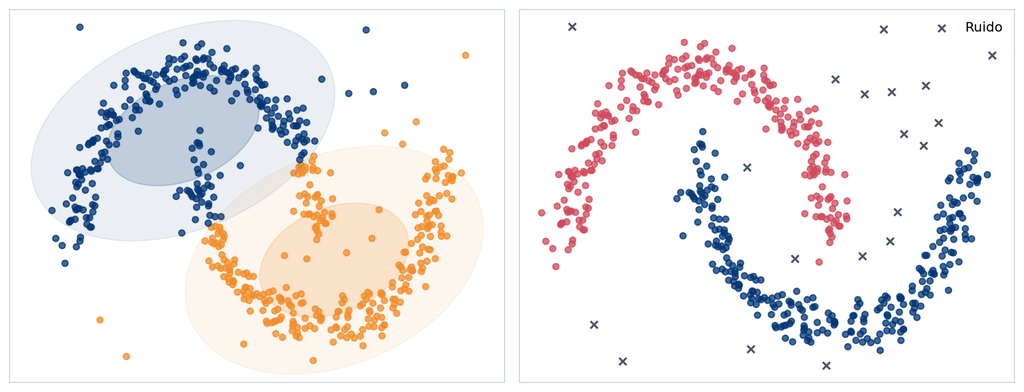

Agrupamiento en formas no convexas con ruido: GMM por elipses (izquierda) frente a DBSCAN por densidad (derecha).

Lunas con ruido: simulación determinista en `country_narrative.py`.

## DBSCAN convierte vecindad en estructura

**DBSCAN** (*Density-Based Spatial Clustering*) agrupa por densidad:

- **Núcleo:** al menos `min_samples` puntos dentro de `eps`.
- **Frontera:** vecino de un núcleo, sin densidad propia.
- **Ruido:** no es núcleo ni frontera.
- Los núcleos densamente alcanzables forman un clúster.

**No exige $K$ y admite formas no convexas.**

## Dos parámetros expresan una escala

```python
from sklearn.cluster import DBSCAN

model = DBSCAN(
    eps=0.16,
    min_samples=8,
)
labels = model.fit_predict(X)
```

**Preguntas**

- ¿Qué significa ser vecino?
- ¿Cuánta evidencia crea un núcleo?
- ¿Cuándo un punto debe ser ruido?

## DBSCAN tampoco es una respuesta universal

- `eps` pequeño fragmenta grupos.
- `eps` grande conecta estructuras distintas.
- Un único `eps` falla con densidades variables.
- En alta dimensión reaparece la concentración de distancias.
- Scikit-Learn no ofrece `predict()` para nuevos puntos.

**HDBSCAN** (*Hierarchical DBSCAN*) extiende la idea a densidades variables.

# Resolver significa explicitar supuestos

## Cada método repara una limitación

| Pregunta que queda abierta | Herramienta siguiente |
| --- | --- |
| ¿Cómo comparar unidades distintas? | Estandarización |
| ¿Cómo mirar nueve variables? | PCA |
| ¿Cómo pasar de vecinos a perfiles? | K-Means |
| ¿Cómo representar duda y anisotropía? | GMM |
| ¿Cómo encontrar formas sin centro y ruido? | DBSCAN |

Ninguna herramienta elimina la necesidad de formular el propósito.

## La respuesta cambia con “respecto a”

| Respecto a… | Más cercano | Distancia $L_2$ | Variables consideradas |
| --- | --- | --- | --- |
| PIB y mortalidad (log + estándar) | Irán | 0,043 | 2 variables transformadas |
| Salud y demografía | Barbados | 0,405 | 4 variables estandarizadas |
| Macroeconomía y comercio | China | 0,362 | 5 variables estandarizadas |
| PCA 2D (visualización) | Argentina | 0,099 | 2 componentes principales |
| Nueve variables (PCA total) | Turquía | 0,749 | Espacio 9D completo |

Todos los resultados provienen del mismo conjunto de datos.

## ¿Cuál respuesta es correcta?

Todas pueden ser correctas bajo una definición particular.

Ninguna es universal.

El algoritmo no descubre qué significa “parecido”; nosotros lo declaramos.

## Cierre: complete la afirmación

Para decidir __________,

compararé a Colombia respecto a __________.

Bajo esa representación, el país más parecido es __________.

## Cuatro ideas para llevar

1. **La representación manda:** variables y escala definen cercanía.
2. **PCA es un mapa:** conserva varianza, pero pierde información.
3. **Cada modelo supone una geometría:** centros, elipses o densidad.
4. **Un clúster es una hipótesis:** debe ser útil, estable e interpretable.

## Segmentar países exige cautela

- Los grupos dependen de variables, año y algoritmo.
- Promedios nacionales esconden desigualdad interna.
- Los nombres valorativos convierten descripción en estigma.
- Una similitud estadística no implica equivalencia histórica.
- Toda decisión necesita revisión humana y contexto.

**Use clustering para formular mejores preguntas, no para fabricar certezas.**

## Tarea: defender una segmentación

1. Auditar las nueve variables y justificar el preprocesamiento.
2. Comparar $K=2,\ldots,8$ con inercia, silueta y estabilidad.
3. Visualizar con PCA sin confundir proyección y entrenamiento.
4. Interpretar perfiles en unidades originales.
5. Completar “parecido respecto a ___ para decidir ___”.

Consulte las instrucciones completas en `homework/Tarea6_KMeans.md`.

## Tarea: lecturas y NotebookLM

- **Obligatorio:** capítulo 9 de *Hands-On Machine Learning* (Géron 2022).
- **Recomendado:** capítulo 8 sobre reducción dimensional (Géron 2022).
- **Opcional:** capítulo 12 de *Introduction to Statistical Learning* (James et al. 2023).
- **Complementario:** capítulo 6 de *Data Science for Business* (Provost y Fawcett 2013).
- [Cuaderno de NotebookLM](https://notebook.google.com/notebook/e3bb0fa0-71fc-49af-ad7a-7b3a57cb6f82): infografía, quices y podcast.

# Anexos

## Muchas dimensiones erosionan la distancia

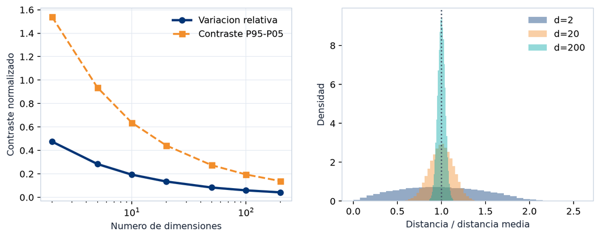

Concentración de distancias en alta dimensión: caída del contraste relativo (izquierda) y convergencia a la media (derecha).

Simulación uniforme reproducible. Generada con `generate_figures.py`.

## Converger no implica el óptimo global

- Cada paso de Lloyd nunca aumenta la inercia.
- Hay un número finito de asignaciones posibles.
- El algoritmo termina en un óptimo local.
- Distintos inicios pueden producir otras soluciones.

```python
KMeans(n_clusters=4, init="k-means++",
       n_init=30, random_state=42)
```

## La silueta contrasta dos distancias

Para la instancia $i$:

$$s(i)=\frac{b(i)-a(i)}{\max\{a(i),b(i)\}}$$

- $a(i)$: distancia media al propio clúster.
- $b(i)$: menor distancia media a otro clúster.
- Cerca de 1 indica una asignación clara.

## Las etiquetas no tienen orden

- Los identificadores `0, 1, 2...` son nombres arbitrarios.
- Dos ejecuciones pueden permutar los números.
- El grupo 2 no es “mayor” que el grupo 1.
- Compare particiones con métricas invariantes a permutaciones.
- Interprete los grupos desde sus perfiles, no desde su número.

## K-Means también crea características

Si existen $K$ centroides, `transform()` produce $K$ distancias:

$$\mathbf x_i \longrightarrow (d_{i1},d_{i2},\ldots,d_{iK})$$

- Resume variables mediante afinidades.
- Puede alimentar un modelo supervisado.
- Debe ajustarse solo con datos de entrenamiento.

## MiniBatch cambia precisión por velocidad

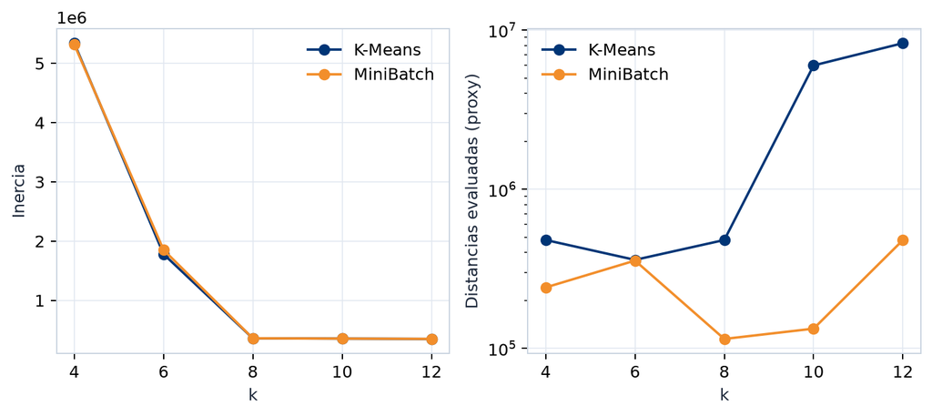

Compromiso entre calidad (inercia similar, izquierda) y costo computacional (menor evaluación de distancias, derecha).

```python
MiniBatchKMeans(n_clusters=k, batch_size=1024,
                n_init=5, random_state=42)
```

## EM alterna responsabilidades y parámetros

El algoritmo **Esperanza-Maximización (EM)** alterna:

1. **E-step:** estima $P(z_i=k\mid\mathbf x_i)$.
2. **M-step:** actualiza pesos, medias y covarianzas.
3. Repite hasta estabilizar la log-verosimilitud.

K-Means y GMM alternan asignar y actualizar; GMM conserva incertidumbre.

## La covarianza controla la geometría

| `covariance_type` | Forma permitida |
| --- | --- |
| `spherical` | Esferas con radios diferentes |
| `diag` | Elipses alineadas con los ejes |
| `tied` | Una covarianza compartida |
| `full` | Forma y orientación por componente |

Más flexibilidad implica más parámetros y riesgo de sobreajuste.

## AIC y BIC seleccionan componentes

Los criterios de información (**AIC** y **BIC**) penalizan la complejidad:

$$\operatorname{AIC}=2p-2\log\hat L,
\qquad
\operatorname{BIC}=p\log n-2\log\hat L$$

- Premian ajuste y penalizan complejidad.
- BIC suele favorecer modelos más simples.
- Compare también estabilidad e interpretación.

## Anomalía y novedad no son sinónimos

- **Anomalías:** el entrenamiento puede contener casos raros.
- **Novedad:** el entrenamiento representa casos normales.
- GMM entrega una densidad, no una decisión automática.
- El umbral depende del costo de cada error.

Una observación rara no es automáticamente error ni fraude.

## PCA también se obtiene mediante SVD

La **Descomposición en Valores Singulares (SVD)** factoriza datos centrados $\mathbf X$:

$$\mathbf X=\mathbf U\boldsymbol\Sigma\mathbf V^\top$$

- $\mathbf V$ contiene las direcciones principales.
- $\boldsymbol\Sigma^2/(n-1)$ contiene sus varianzas.
- Las primeras columnas dan una aproximación de rango bajo.

## Reproducir el caso de Colombia

Desde la raíz del repositorio:

```bash
python quarto/clustering/country_narrative.py --all
```

El script valida vecinos, modelos y varianza explicada, y genera un CSV auditable.

## Reproducir las figuras complementarias

Desde `quarto/clustering`:

```bash
python generate_figures.py --all
```

Dependencias declaradas en `quarto/clustering/requirements.txt`.

## Referencias

Géron, Aurélien. 2022. *Hands-on machine learning with Scikit-Learn, Keras, and TensorFlow: Concepts, tools, and techniques to build intelligent systems*. " O’Reilly Media, Inc.".

James, Gareth, Daniela Witten, Trevor Hastie, Robert Tibshirani, y Jonathan Taylor. 2023. *An Introduction to Statistical Learning: with Applications in Python*. Springer Nature.

Provost, Foster, y Tom Fawcett. 2013. *Data Science for Business: What You Need to Know about Data Mining and Data-Analytic Thinking*. O’Reilly Media, Inc.